# ETH-prediction-rnn

### ETH prediction

This article explores the long short-term memory (LSTM) network and how it can be used to make ETH market predictions comparing to ARMA model.

### P1 Data preprocessing

```python
import numpy as np
import pandas as pd
import matplotlib.pyplot as plt
```

```python
dataset_train = pd.read_csv("./ETH_trainset.csv")
```

```python
dataset_train
```

|  | Date | Open | High | Low | Close | Volume | Transaction | Avg | Turnover |
| --- | --- | --- | --- | --- | --- | --- | --- | --- | --- |
| 0 | 2016/1/4 | 2.201887 | 2.203713 | 2.074030 | 2.080422 | 298546954 | 703760451 | 2.152831 | 2.406860 |
| 1 | 2016/1/5 | 2.063984 | 2.110560 | 2.036586 | 2.087729 | 645699581 | 1473642292 | 2.084296 | 5.069479 |
| 2 | 2016/1/6 | 2.091382 | 2.118780 | 2.077683 | 2.116040 | 400953404 | 921398473 | 2.098705 | 3.178638 |
| 3 | 2016/1/7 | 2.087729 | 2.087729 | 1.977223 | 1.988182 | 89166922 | 199851686 | 2.046925 | 0.706441 |
| 4 | 2016/1/8 | 2.042065 | 2.063070 | 1.969004 | 2.026540 | 576676937 | 1279000234 | 2.025517 | 4.563040 |
| ... | ... | ... | ... | ... | ... | ... | ... | ... | ... |
| 1195 | 2020/12/1 | 3.476000 | 3.563000 | 3.476000 | 3.557000 | 811632065 | 2864395143 | 3.529179 | 5.120524 |
| 1196 | 2020/12/2 | 3.558000 | 3.573000 | 3.525000 | 3.545000 | 541549798 | 1922213431 | 3.549468 | 3.377095 |
| 1197 | 2020/12/3 | 3.544000 | 3.552000 | 3.521000 | 3.538000 | 545270803 | 1927642645 | 3.535202 | 3.333141 |
| 1198 | 2020/12/4 | 3.535000 | 3.549000 | 3.501000 | 3.543000 | 442716436 | 1560214891 | 3.524186 | 2.713261 |
| 1199 | 2020/12/7 | 3.544000 | 3.549000 | 3.492000 | 3.511000 | 486309440 | 1708975464 | 3.514173 | 3.011658 |

1200 rows × 9 columns

Statistic description

```python
dataset_train.describe()
```

|  | Open | High | Low | Close | Volume | Transaction | Avg | Turnover |
| --- | --- | --- | --- | --- | --- | --- | --- | --- |
| count | 1200.000000 | 1200.000000 | 1200.000000 | 1200.000000 | 1.200000e+03 | 1.200000e+03 | 1200.000000 | 1200.000000 |
| mean | 2.541748 | 2.561777 | 2.524633 | 2.543779 | 4.880979e+08 | 1.336211e+09 | 2.543682 | 3.364845 |
| std | 0.402380 | 0.405934 | 0.399084 | 0.402597 | 3.267784e+08 | 9.434541e+08 | 0.402112 | 1.960748 |
| min | 1.751646 | 1.785437 | 1.726075 | 1.748906 | 7.785455e+07 | 1.719694e+08 | 1.754479 | 0.636029 |
| 25% | 2.208369 | 2.218636 | 2.199316 | 2.207904 | 2.591224e+08 | 6.586369e+08 | 2.209953 | 1.976679 |
| 50% | 2.543266 | 2.559785 | 2.531317 | 2.545158 | 4.163454e+08 | 1.162825e+09 | 2.545532 | 2.988435 |
| 75% | 2.832092 | 2.856339 | 2.816171 | 2.835189 | 6.238289e+08 | 1.762519e+09 | 2.833810 | 4.276485 |
| max | 3.558000 | 3.575000 | 3.525000 | 3.557000 | 2.599900e+09 | 7.843001e+09 | 3.549468 | 14.991264 |

Using open price as the predicting target

```python
trainset = dataset_train.iloc[:,1:2].values
```

Min_max scaler is applied for faster trainning speed.

```python
from sklearn.preprocessing import MinMaxScaler
scaler = MinMaxScaler(feature_range = (0,1))
training_scaled = scaler.fit_transform(trainset)
```

```python
x_train = []
y_train = []
```

Since this is a time series data, I assume the datapoint can be predicted by previous 60 datapoints. Why 60? In stock market, 60 day MACD line is an important feature to predict the price of a stock. I tried 20 datapoints as features (MACD 20 line is also important in stock analysis.), but the results are bad comparing to 60 datapoints.

```python
for i in range(60,trainset.shape[0]):
    x_train.append(training_scaled[i-60:i, 0])
    y_train.append(training_scaled[i,0])
x_train,y_train = np.array(x_train),np.array(y_train)
```

```python
x_train = np.reshape(x_train, (x_train.shape[0],x_train.shape[1],1))
```

### P2.Build LSTM

LSTM (long short-term memory network) is a variant of RNN. RNN and conventional neural network is different from the layer of neurons between the establishment of a connection. The advantage is that it is convenient to use the sequence of before and after correlation analysis of time series. However, RNN ,due to gradient disappearance reasons, can only have short-term memory. LSTM network uses gate control of short-term memory and long-term memory combined, to solve the problem of gradient disappearance, resulting in better prediction sequence situation.

```python
from keras.models import Sequential
from keras.layers import Dense
from keras.layers import LSTM
from keras.layers import Dropout
```

```python
model = Sequential()
model.add(LSTM(units = 60,return_sequences = True,input_shape = (x_train.shape[1],1)))
model.add(Dropout(0.4))
model.add(LSTM(units = 60,return_sequences = True))
model.add(Dropout(0.4))
model.add(LSTM(units = 60,return_sequences = True))
model.add(Dropout(0.4))
model.add(LSTM(units = 60,return_sequences = True))
model.add(Dropout(0.4))
model.add(LSTM(units = 60))
model.add(Dropout(0.4))
model.add(Dense(units = 1))
```

```python
model.compile(optimizer = 'adam',loss = 'mean_squared_error')
```

```python
model.summary()
```

```
Model: "sequential"
_________________________________________________________________
Layer (type)                 Output Shape              Param #
=================================================================
lstm (LSTM)                  (None, 60, 60)            14880
_________________________________________________________________
dropout (Dropout)            (None, 60, 60)            0
_________________________________________________________________
lstm_1 (LSTM)                (None, 60, 60)            29040
_________________________________________________________________
dropout_1 (Dropout)          (None, 60, 60)            0
_________________________________________________________________
lstm_2 (LSTM)                (None, 60, 60)            29040
_________________________________________________________________
dropout_2 (Dropout)          (None, 60, 60)            0
_________________________________________________________________
lstm_3 (LSTM)                (None, 60, 60)            29040
_________________________________________________________________
dropout_3 (Dropout)          (None, 60, 60)            0
_________________________________________________________________
lstm_4 (LSTM)                (None, 60)                29040
_________________________________________________________________
dropout_4 (Dropout)          (None, 60)                0
_________________________________________________________________
dense (Dense)                (None, 1)                 61
=================================================================
Total params: 131,101
Trainable params: 131,101
Non-trainable params: 0
_________________________________________________________________
```

### P3. Model Trainning

```python
model.fit(x_train,y_train,epochs = 100, batch_size = 32)
```

```
<tensorflow.python.keras.callbacks.History at 0x1a99f3b5518>
```

### P4.Prediction

```python
dataset_test = pd.read_csv("./ETH_testset.csv")
```

```python
dataset_test
```

|  | Date | Open | High | Low | Close | Volume | Transaction | Avg | Turnover |
| --- | --- | --- | --- | --- | --- | --- | --- | --- | --- |
| 0 | 2020/12/8 | 3.580 | 3.580 | 3.488 | 3.499 | 436983773 | 1535311280 | 3.513429 | 2.675029 |
| 1 | 2020/12/9 | 3.507 | 3.520 | 3.465 | 3.470 | 512286103 | 1791501940 | 3.497073 | 3.118815 |
| 2 | 2020/12/10 | 3.461 | 3.477 | 3.439 | 3.456 | 458333410 | 1586191032 | 3.460780 | 2.805722 |
| 3 | 2020/12/11 | 3.469 | 3.478 | 3.403 | 3.429 | 540670655 | 1857613082 | 3.435757 | 3.336780 |
| 4 | 2020/12/14 | 3.435 | 3.466 | 3.430 | 3.461 | 303408537 | 1046907314 | 3.450487 | 1.874690 |
| ... | ... | ... | ... | ... | ... | ... | ... | ... | ... |
| 198 | 2021/9/29 | 3.225 | 3.260 | 3.195 | 3.248 | 767053532 | 2479461267 | 3.232449 | 4.634802 |
| 199 | 2021/9/30 | 3.248 | 3.250 | 3.222 | 3.231 | 521097066 | 1685853875 | 3.235201 | 3.188529 |
| 200 | 2021/10/8 | 3.262 | 3.300 | 3.258 | 3.295 | 734601345 | 2416701710 | 3.289814 | 4.527850 |
| 201 | 2021/10/11 | 3.309 | 3.353 | 3.306 | 3.312 | 881909167 | 2932563131 | 3.325244 | 5.568007 |
| 202 | 2021/10/12 | 3.300 | 3.322 | 3.271 | 3.295 | 703599890 | 2318202782 | 3.294774 | 4.442236 |

203 rows × 9 columns

```python
dataset_total = pd.concat((dataset_train['Open'],dataset_test['Open']),axis = 0)
```

```python
real_eth_price = dataset_test.iloc[:,1:2].values
```

```python
input_data = dataset_total[len(dataset_total) - len(dataset_test)-60:].values
input_data.shape
```

```
(263,)
```

```python
input_data = input_data.reshape(-1,1)
```

```python
input_data = scaler.transform(input_data)
input_data.shape
```

```
(263, 1)
```

```python
x_test = []
for i in range(60,258):
    x_test.append(input_data[i-60:i,0])
```

```python
x_test = np.array(x_test)
```

```python
x_test = np.reshape(x_test, (x_test.shape[0],x_test.shape[1],1))
```

```python
pred = model.predict(x_test)
```

```python
pred = scaler.inverse_transform(pred)
```

### P5. Result Visualization

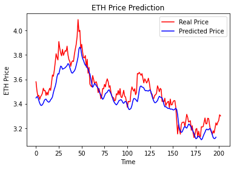

```python
plt.plot(real_eth_price,color = 'red', label = 'Real Price')
plt.plot(pred, color = 'blue', label = 'Predicted Price')
plt.title('ETH Price Prediction')
plt.xlabel('Time')
plt.ylabel('ETH Price')
plt.legend()
plt.show()
```

Comparing to ARMA model

```
(1403,)
```

```
Testing Mean Squared Error is 0.002187911583310571
```

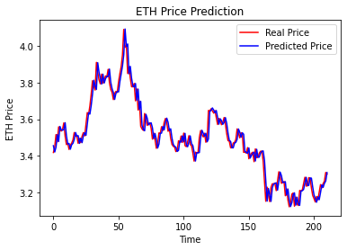

```python
# reference: https://towardsdatascience.com/time-series-forecasting-predicting-stock-prices-using-an-arima-model-2e3b3080bd70
from statsmodels.tsa.arima_model import ARIMA
from sklearn.metrics import mean_squared_error

dataset_total = pd.concat((dataset_train['Open'],dataset_test['Open']),axis = 0)

print(dataset_total.shape)

input_data = dataset_total[:].values

input_data = input_data.reshape(-1,1)

train_data, test_data = input_data[0:int(len(input_data)*0.85)], input_data[int(len(input_data)*0.85):]
training_data = train_data
test_data = test_data
history = [x for x in training_data]
model_predictions = []
N_test_observations = len(test_data)
for time_point in range(N_test_observations):
    model = ARIMA(history, order=(4,1,0))
    model_fit = model.fit(disp=0)
    output = model_fit.forecast()
    yhat = output[0]
    model_predictions.append(yhat)
    true_test_value = test_data[time_point]
    history.append(true_test_value)
MSE_error = mean_squared_error(test_data, model_predictions)
print('Testing Mean Squared Error is {}'.format(MSE_error))

plt.plot(test_data,color = 'red', label = 'Real Price')
plt.plot(model_predictions, color = 'blue', label = 'Predicted Price')
plt.title('ETH Price Prediction')
plt.xlabel('Time')
plt.ylabel('ETH Price')
plt.legend()
plt.show()
```